# SQL - Lenguaje de Consulta Estructurado

## Cláusula HAVING

Para seleccionar filas en función de los resultados de una función de resumen se usa la cláusula *HAVING*. La cláusula *HAVING* es similar a la cláusula *WHERE* en que permite seleccionar filas para mantener en el conjunto de resultados de su consulta. Es una cláusula opcional y se coloca después de la cláusula *GROUP BY*.

[figure not shown]

```r
    proc sql;
      select depart length=15,
           prov,
           sum(TPob) as TotalTPob length=7
      from datos.Tpob_localidades
      group by prov, depart;
      having TotalTPob gt 50000;
    quit;
```

En la consulta anterior, la condición de la cláusula *HAVING* (TotalTPob > 50000) se evalúa después de que la consulta se haya ejecutado y las filas se hayan agrupado y solo las filas que cumplan la condición se escribirán en el conjunto de resultados.

Es importante destacar la diferencia entre las cláusulas *HAVING* y *WHERE*. La cláusula *WHERE* selecciona filas a medida que entran en la consulta. Tiene que hacer referencia a columnas que existen en la tabla de consulta o que se calculan utilizando columnas en las tablas de consulta. No puede hacer referencia a columnas de resumen. La cláusula *HAVING*, por otro lado, hace referencia a columnas de resumen a medida que las filas salen de la consulta.

¿Qué sucede si usa la cláusula *HAVING* en columnas sin resumen? Depende mucho del resto de *SELECT*. Si no tiene columnas de resumen, las cláusulas *WHERE* y *HAVING* producirán resultados idénticos. Por ejemplo, estas dos consultas producen exactamente el mismo resultado.

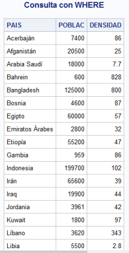

```r
    proc sql;
        select pais,
        poblac,
        densidad
        from Datos.Mundo
        where relig eq 'Musulmana';
    quit;
```

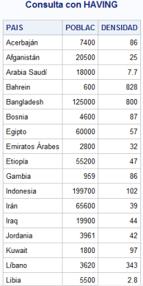

```r
    proc sql;
        select pais,
        poblac,
        densidad
        from Datos.Mundo
        having relig eq 'Musulmana';
    quit;
```

No hay un resumen de las filas, por lo que los valores que entran y los que salen de la consulta son los mismos. Sin embargo, existe una gran diferencia cuando hay una función resumen en el comando *SELECT* y la cláusula *HAVING* hace referencia a una columna no resumida.

# Consultas SQL utilzando R

Este material cubre solo la sintaxis de las consultas **SQL** utilizando el paquete *sqldf* (https://cran.r-project.org/web/packages/sqldf/index.html) que permite las consultas **SQL**.

## Función sqldf

La función sqldf() generalmente lleva un único argumento que es una instrucción de selección **SQL** donde los nombres de las tablas son nombres de conjuntos de datos R ordinarios.

```r
      library("sqldf")
```

El paquete *sqldf* es simple, desde el punto de vista de R hay una sola función por la que estár preocupados, y es: como se pasa a la función *sqldf()* una instrucción **SQL**.

```r
      sqldf('SELECT age, circumference FROM Naranjo WHERE Tree = 1
            ORDER BY circumference')
```

```
##    age circumference
## 1  118            30
## 2  484            58
## 3  664            87
## 4 1004           115
## 5 1231           120
## 6 1372           142
## 7 1582           145
```

## Consultas SQL

Como se ha visto anteriormente en el curso, existe una gran cantidad de comandos principales de **SQL**, las consultas se realizan con el comando SELECT.

```r
      sqldf("SELECT * FROM iris")
      sqldf("select * from iris")
```

Los dos formas de escribir el comandos son equivalentes,

Una nota sobre la convención **SQL**:

El siguiente comando fallaría suponiendo que no se haya creado un nuevo objeto llamado “IRIS”:

```r
      sqldf("SELECT * from IRIS")
```

Recordando, la sintaxis básica para *SELECT* es:

```r
      SELECT variable1, variable2 FROM data
```

En el siguiente ejemplo se presenta el comando SELECT para la función *sqldf()*

```r
      BOD
```

```
##   Time demand
## 1    1    8.3
## 2    2   10.3
## 3    3   19.0
## 4    4   16.0
## 5    5   15.6
## 6    7   19.8
```

```r
      sqldf('SELECT demand FROM BOD')
```

```
##   demand
## 1    8.3
## 2   10.3
## 3   19.0
## 4   16.0
## 5   15.6
## 6   19.8
```

*Nota*: **SQL** no acepta las variables con punto (.) en el nombre, y si lo tiene, debe colocase el nombre de la variable de consulta entre comillas.

```r
iris1 <- sqldf('SELECT Petal.Width FROM iris')

# Error: no such column: Petal.Width
```

```r
iris2 <- sqldf('SELECT "Petal.Width" FROM iris')
```

### COMODÍN Asterisco (*)

Se puede especificar un comodín asterisco para extraer todo.

```r
      bod2 <- sqldf('SELECT * FROM BOD')
```

### Cláusulas

- **LÍMIT**

Se utiliza para controlar el número de resultados devueltos.

```r
      sqldf('SELECT * FROM iris LIMIT 5')
```

```
##   Sepal.Length Sepal.Width Petal.Length Petal.Width Species
## 1          5.1         3.5          1.4         0.2  setosa
## 2          4.9         3.0          1.4         0.2  setosa
## 3          4.7         3.2          1.3         0.2  setosa
## 4          4.6         3.1          1.5         0.2  setosa
## 5          5.0         3.6          1.4         0.2  setosa
```

- **ORDER BY**

Permite ordenar variables usando la siguiente sintaxis:

```r
      ORDER BY var1 {ASC/DESC}, var2 {ASC/DESC}
```

Donde la especificación de *ASC* para *ascendente* o *DESC* para *descendente* se realiza por variable.

```r
      sqldf("SELECT * FROM Naranjo ORDER BY age ASC, circumference
            DESC LIMIT 5")
```

```
##   Tree age circumference
## 1    2 118            33
## 2    4 118            32
## 3    1 118            30
## 4    3 118            30
## 5    5 118            30
```

- **WHERE**

Las declaraciones condicionales se pueden agregar a través de *WHERE*:

```r
      sqldf('SELECT demand FROM BOD WHERE Time < 3')
```

```
##   demand
## 1    8.3
## 2   10.3
```

- **AND y OR**

Los operadores *AND* y *OR* son válidos para especificar cierto orden de las operaciones en la selección, si se usan juntos es aconsejable separar con paréntesis para especificar el orden.

```r
      sqldf('SELECT * FROM rock WHERE (peri > 5000 AND shape < .05)
            OR perm > 1000')
```

```
##   area     peri    shape perm
## 1 5048  941.543 0.328641 1300
## 2 1016  308.642 0.230081 1300
## 3 5605 1145.690 0.464125 1300
## 4 8793 2280.490 0.420477 1300
```

Hay algunas formas más complicadas de usar *WHERE*:

- **IN**

*WHERE IN* se usa de manera similar a %in% de **R**. También es compatible *NOT*.

```r
      sqldf('SELECT * FROM BOD WHERE Time IN (1,7)')
```

```
##   Time demand
## 1    1    8.3
## 2    7   19.8
```

```r
      sqldf('SELECT * FROM BOD WHERE Time NOT IN (1,7)')
```

```
##   Time demand
## 1    2   10.3
## 2    3   19.0
## 3    4   16.0
## 4    5   15.6
```

- **LIKE**

*LIKE* puede considerarse como un comando de expresión regular débil. Solo permite el comodín % único que coincide con cualquier número de caracteres. Por ejemplo, para extraer los datos donde el feed termina con “bean”:

```r
      sqldf('SELECT * FROM chickwts WHERE feed LIKE "%bean" LIMIT 5')
```

```
##   weight      feed
## 1    179 horsebean
## 2    160 horsebean
## 3    136 horsebean
## 4    227 horsebean
## 5    217 horsebean
```

```r
      sqldf('SELECT * FROM chickwts WHERE feed NOT LIKE "%bean" LIMIT 5')
```

```
##   weight    feed
## 1    309 linseed
## 2    229 linseed
## 3    181 linseed
## 4    141 linseed
## 5    260 linseed
```

### Datos agregados

*SELECT* pueden crear utilizando los datos agregados *AVG*, *MEDIAN*, *MAX*, *MIN* y *SUM* como funciones de la lista de variables para seleccionar. La declaración GROUP BY se puede agregar al agregado por grupos. Se puede nombrar el *AS*.

```r
      sqldf("SELECT AVG(circumference) FROM Naranjo")
```

```
##   AVG(circumference)
## 1           115.8571
```

```r
      sqldf("SELECT tree, AVG(circumference) AS meancirc FROM Naranjo
            GROUP BY tree")
```

```
##   Tree  meancirc
## 1    1  99.57143
## 2    2 135.28571
## 3    3  94.00000
## 4    4 139.28571
## 5    5 111.14286
```

**Conteo de datos**

*SELECT COUNT()* Devuelve el número de observaciones. Pasar * o nada devuelve las *k* totales, pasar un nombre de variable devuelve el número de entradas que no son *NA*. *AS* funciona igual de bien

```r
      d <- data.frame(a = c(1,1,1), b = c(1,NA,NA))
      d
```

```
##   a  b
## 1 1  1
## 2 1 NA
## 3 1 NA
```

```r
      sqldf("SELECT COUNT() as numrows FROM d")
```

```
##   numrows
## 1       3
```

```r
      sqldf("SELECT COUNT(b) FROM d")
```

```
##   COUNT(b)
## 1        1
```